# Part II - Effects of rental characteristics on Rental Duration

## by Nam Vu Hoang

## Investigation Overview

In the data explanatory, I want to have a look at the features of bike rental data that could be used to predict or affect the rental duration. The main focus will be on the duration (in seconds) because it is highly correlated with rental fees. The main features correlated with durations are start and end hour, month, rideable_type, member_casual

## Dataset Overview

Each trip includes:

Bike ID

Bike Type

Start Time and Date

End Time and Date

Start Station ID

Start Station Name

Start Station Latitude

Start Station Longitude

End Station ID

End Station Name

End Station Latitude

End Station Longitude

User Type

|  | ride_id | rideable_type | started_at | ended_at | start_station_name | start_station_id | end_station_name | end_station_id | start_lat | start_lng | end_lat | end_lng | member_casual |
| --- | --- | --- | --- | --- | --- | --- | --- | --- | --- | --- | --- | --- | --- |
| 0 | CC1B49543825D43C | classic_bike | 2024-01-10 17:51:51 | 2024-01-10 17:57:03 | Adeline St at 40th St | EM-D4 | Genoa St at 55th St | OK-D2 | 37.831277 | -122.278267 | 37.839649 | -122.271756 | member |
| 1 | DAD85B04AC2FE762 | electric_bike | 2024-01-18 17:16:16 | 2024-01-18 17:25:23 | Valencia St at 16th St | SF-M22-2 | 29th St at Church St | SF-T20 | 37.765303 | -122.421842 | 37.743684 | -122.426806 | member |
| 2 | DFC8F18E5862DA0C | electric_bike | 2024-01-10 17:05:41 | 2024-01-10 17:20:03 | Mechanics Monument Plaza (Market St at Bush St) | SF-F28-1 | Brannan St at 7th St | SF-K27-2 | 37.791315 | -122.398834 | 37.772438 | -122.403924 | member |
| 3 | C431CBFB24AD4C1D | classic_bike | 2024-01-27 13:50:50 | 2024-01-27 14:00:26 | Beale St at Harrison St | SF-G30-1 | Brannan St at 7th St | SF-K27-2 | 37.787963 | -122.391808 | 37.772438 | -122.403924 | casual |
| 4 | 11963D1C987A38FA | electric_bike | 2024-01-28 15:27:55 | 2024-01-28 15:48:06 | Mechanics Monument Plaza (Market St at Bush St) | SF-F28-1 | Greenwich St at Franklin St | SF-B21 | 37.791385 | -122.398798 | 37.800287 | -122.425786 | casual |

```
count    2.242834e+06
mean     7.598656e+02
std      1.252651e+03
min     -1.000000e+00
25%      3.293870e+02
50%      5.508710e+02
75%      8.830000e+02
max      8.969600e+04
Name: duration, dtype: float64
```

## Distribution of Duration (in seconds)

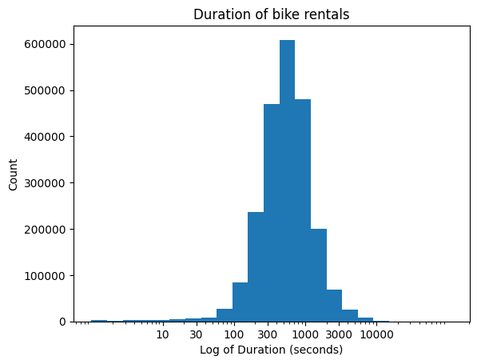

## Duratons vs the time members started riding bikes

Heatmap plotting duration and the time members started riding bikes (in hours) spotlights the period member riding the most. There are extreme many members who ride bikes at 8 and 17.

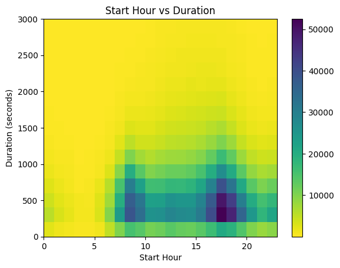

## Duration vs the month members started riding bikes

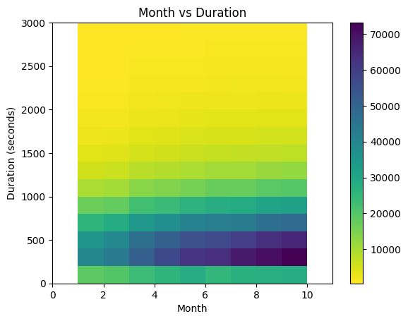

## Duration and Month by User type

In both member and casual users group, we can see that the number of rental bikes are increasing from January to September of 2024 and it reaches the top in September. However, members ride bikes shorter in general than casual users.

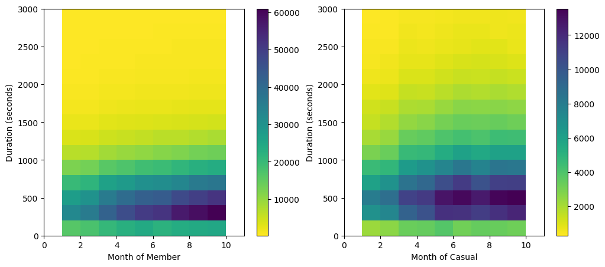

## Duration and rideable type by User Type

In both two types of bikes, members ride shorter than casual riders but it is much higher in classic bike

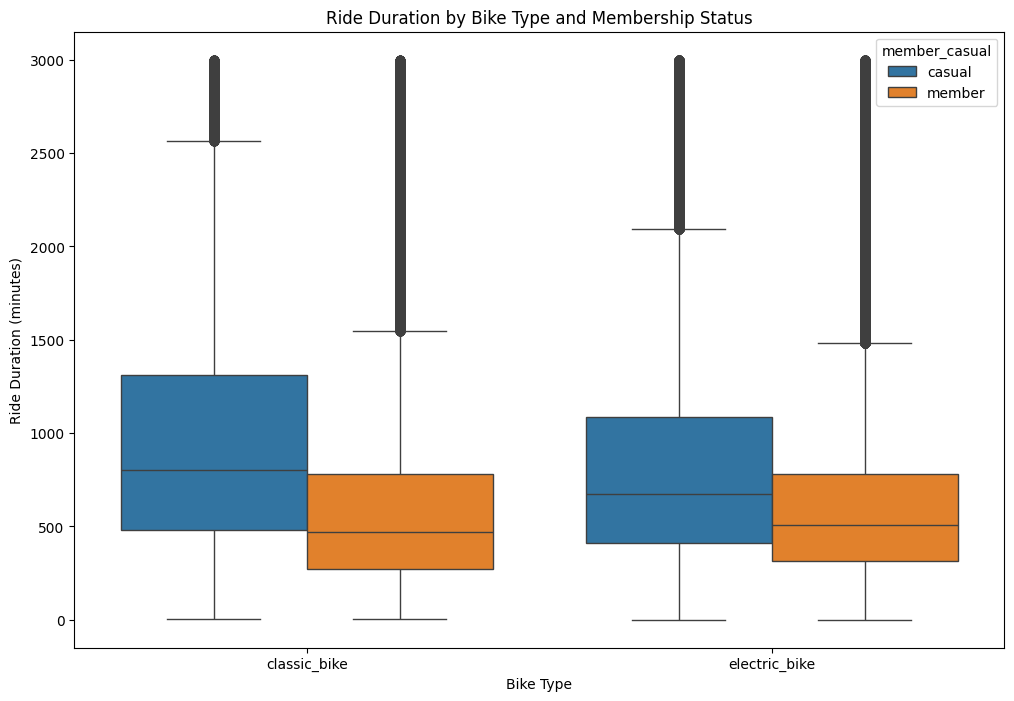